# project

```python
import pandas as pd
import matplotlib.pyplot as plt
import numpy as np
from sipri_interface import sipri_caller
import pickle
from pandas import json_normalize
import os
import math
import plotly.graph_objects as go
```

```python
pd.reset_option('display.max_columns')
pd.reset_option('display.width')
```

```python
cutoff_year = 1995
years = np.arange(cutoff_year,2024,1)
N = 5
pd.set_option('display.max_rows', 500)
pd.set_option('display.max_columns', 500)
pd.set_option('display.width', 1000)
```

```python
# Load the CSV files
exports_data = pd.read_csv('./export-values_1990-2023.csv', skiprows=8)
imports_data = pd.read_csv('./import-values_1990-2023.csv', skiprows=8)
suppliers_data = pd.read_csv('./regional-transfers_1990-2023-suppliers_to_the_region.csv', skiprows=10)
```

```python
exports_data.head()
```

|  | Exports by | 1990 | 1991 | 1992 | 1993 | 1994 | 1995 | 1996 | 1997 | 1998 | 1999 | 2000 | 2001 | 2002 | 2003 | 2004 | 2005 | 2006 | 2007 | 2008 | 2009 | 2010 | 2011 | 2012 | 2013 | 2014 | 2015 | 2016 | 2017 | … |
| --- | --- | --- | --- | --- | --- | --- | --- | --- | --- | --- | --- | --- | --- | --- | --- | --- | --- | --- | --- | --- | --- | --- | --- | --- | --- | --- | --- | --- | --- | --- |
| 0 | United States | 10664.0 | 12484.0 | 14083.0 | 13766.0 | 11483.0 | 11177.0 | 10839.0 | 14498.0 | 15708.0 | 11538.0 | 7662.0 | 5600.0 | 4882.0 | 5643.0 | 6839.0 | 6738.0 | 7533.0 | 7956.0 | 7150.0 | 7191.0 | 8389.0 | 9024.0 | 8956.0 | 7694.0 | 9490.0 | 9868.0 | 9465.0 | 11444.0 | … |
| 1 | Russia | NaN | NaN | 2639.0 | 3484.0 | 1533.0 | 3849.0 | 3610.0 | 3428.0 | 2062.0 | 4295.0 | 4492.0 | 5387.0 | 5840.0 | 5196.0 | 6290.0 | 5153.0 | 5135.0 | 5560.0 | 5993.0 | 5087.0 | 6240.0 | 8798.0 | 8275.0 | 7780.0 | 5335.0 | 5788.0 | 6706.0 | 6376.0 | … |
| 2 | France | 1825.0 | 1196.0 | 1247.0 | 974.0 | 861.0 | 960.0 | 1850.0 | 3187.0 | 3132.0 | 1758.0 | 1033.0 | 1383.0 | 1393.0 | 1362.0 | 2140.0 | 1663.0 | 1497.0 | 2154.0 | 1889.0 | 1854.0 | 884.0 | 2248.0 | 1326.0 | 1799.0 | 1768.0 | 2271.0 | 2141.0 | 2315.0 | … |
| 3 | Germany | 1835.0 | 2418.0 | 1526.0 | 1559.0 | 2920.0 | 1552.0 | 1961.0 | 957.0 | 1851.0 | 1878.0 | 1646.0 | 869.0 | 902.0 | 1652.0 | 1103.0 | 2088.0 | 2485.0 | 3296.0 | 2380.0 | 2208.0 | 2357.0 | 1204.0 | 729.0 | 729.0 | 1822.0 | 1812.0 | 2509.0 | 1841.0 | … |
| 4 | United Kingdom | 1837.0 | 1510.0 | 1093.0 | 1382.0 | 1513.0 | 1450.0 | 1608.0 | 2359.0 | 1400.0 | 1315.0 | 1623.0 | 1359.0 | 1076.0 | 769.0 | 1217.0 | 991.0 | 954.0 | 920.0 | 927.0 | 1073.0 | 1152.0 | 1007.0 | 817.0 | 1493.0 | 1658.0 | 1183.0 | 1324.0 | 1107.0 | … |

```python
# Process each year from 1990 to 2023
top_10_each_year = {}

for year in years:  # 2023 inclusive
    # Assuming each column is named as the year
    year_str = str(year)
    if year_str in exports_data.columns:
        # Sort by the year column descending, take the top 12(accounting for total world), and store the result
        top_countries = exports_data.sort_values(by=year_str, ascending=False).head(11)
        top_10_each_year[year] = top_countries['Exports by'][1:]

#save the top 10 countries in each year
```

```python
top_10_countries_years = set()
for year, countries in top_10_each_year.items():
    top_10_countries_years.update(countries)

print(top_10_countries_years)
```

```
{'Russia', 'Netherlands', 'United Kingdom', 'China', 'France', 'Canada', 'Sweden', 'South Korea', 'Italy', 'Israel', 'United States', 'Ukraine', 'Belarus', 'Spain', 'Germany', 'Switzerland', 'Turkiye'}
```

[figure not shown]

```python
top_10_exporters_range = exports_data[exports_data['Exports by'].isin(top_10_countries_years)]

top_10_exporters_range.fillna(0, inplace=True)

df = top_10_exporters_range
# Assuming 'df' is your main DataFrame.

# Sort countries by 'Sum total years' in descending order
sorted_countries = df.sort_values('Sum total years', ascending=False)['Exports by'].tolist()

# Now, sorted_countries contains the names of the countries sorted by their total exports.

# Set 'Exports by' as the index if it's not already
df.set_index('Exports by', inplace=True)

# Drop the unnecessary columns
df_years = df.drop(columns=['1990-2023', 'Percentage', 'Sum total years', 'Percentage of total'])

# Transpose the DataFrame so that each column becomes a country and rows are years
df_transposed = df_years.transpose()

# Plotting
plt.figure(figsize=(15, 10))  # Set figure size
top_exporters = sorted_countries[:N]
for country in top_exporters:
    # Check if country is in the columns of the transposed DataFrame
    if country in df_transposed.columns:
        plt.plot(df_transposed.index, df_transposed[country], marker='', linewidth=2, label=country)

plt.title('Top 10 Export Values by Country from 1995 to 2023')
plt.xlabel('Year')
plt.ylabel('TIV Export Value')
plt.xticks(rotation=45)  # Rotate the x-axis labels for better readability
plt.legend(title='Country', loc='upper left', bbox_to_anchor=(1, 1))  # Place legend outside the plot
plt.grid(True, which='both', axis='y', linestyle='--', linewidth=0.5, color='gray')  # Add a grid for easier reading of values

plt.tight_layout()  # Adjust layout to make room for legend
plt.show()
```

```python
#TODO come with an update on the biggest importers in the world over the same period
imports_data.head()
```

|  | Recipient | 1990 | 1991 | 1992 | 1993 | 1994 | 1995 | 1996 | 1997 | 1998 | 1999 | 2000 | 2001 | 2002 | 2003 | 2004 | 2005 | 2006 | 2007 | 2008 | 2009 | 2010 | 2011 | 2012 | 2013 | 2014 | 2015 | 2016 | 2017 | … |
| --- | --- | --- | --- | --- | --- | --- | --- | --- | --- | --- | --- | --- | --- | --- | --- | --- | --- | --- | --- | --- | --- | --- | --- | --- | --- | --- | --- | --- | --- | --- |
| 0 | India | 2832.0 | 1873.0 | 1187.0 | 735.0 | 872.0 | 1396.0 | 822.0 | 1665.0 | 797.0 | 1212.0 | 987.0 | 1169.0 | 2001.0 | 2738.0 | 2212.0 | 1194.0 | 1479.0 | 2276.0 | 1624.0 | 1937.0 | 2886.0 | 3613.0 | 4429.0 | 5242.0 | 3201.0 | 2724.0 | 2553.0 | 2656.0 | … |
| 1 | Saudi Arabia | 2039.0 | 1038.0 | 1153.0 | 2358.0 | 981.0 | 983.0 | 1724.0 | 2790.0 | 2886.0 | 1580.0 | 105.0 | 60.0 | 560.0 | 160.0 | 1159.0 | 166.0 | 205.0 | 227.0 | 387.0 | 827.0 | 1108.0 | 1172.0 | 930.0 | 1511.0 | 2711.0 | 3384.0 | 2974.0 | 3968.0 | … |
| 2 | China | 312.0 | 483.0 | 1196.0 | 1243.0 | 320.0 | 716.0 | 1511.0 | 949.0 | 382.0 | 1730.0 | 2491.0 | 2773.0 | 2838.0 | 2334.0 | 3236.0 | 3478.0 | 2842.0 | 1700.0 | 1822.0 | 1386.0 | 979.0 | 1071.0 | 1601.0 | 1261.0 | 1041.0 | 1252.0 | 1223.0 | 1550.0 | … |
| 3 | South Korea | 1214.0 | 921.0 | 795.0 | 1024.0 | 1029.0 | 1965.0 | 1984.0 | 1230.0 | 1417.0 | 1636.0 | 1399.0 | 774.0 | 520.0 | 754.0 | 1055.0 | 802.0 | 1659.0 | 1730.0 | 1691.0 | 798.0 | 1299.0 | 1568.0 | 1076.0 | 189.0 | 742.0 | 268.0 | 1038.0 | 962.0 | … |
| 4 | Turkiye | 1241.0 | 1270.0 | 1879.0 | 2329.0 | 1891.0 | 1567.0 | 1491.0 | 1512.0 | 2627.0 | 1734.0 | 1182.0 | 506.0 | 893.0 | 331.0 | 257.0 | 1094.0 | 529.0 | 701.0 | 649.0 | 731.0 | 467.0 | 756.0 | 1481.0 | 769.0 | 1527.0 | 445.0 | 328.0 | 429.0 | … |

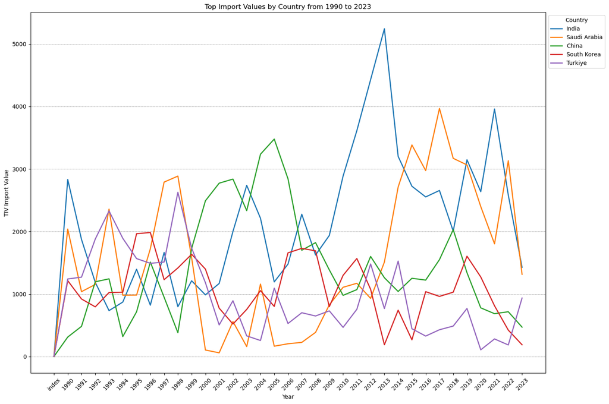

```python
import matplotlib.pyplot as plt
import pandas as pd

# Assuming 'imports_data' is your DataFrame containing the import data.
df = imports_data

# Make sure to reset the index in case 'Recipient' is not a column.
df.reset_index(inplace=True)

# Now 'Recipient' is definitely a column and not the index.

# Remove the 'Total world import' row if present
df = df[df['Recipient'] != 'Total world import']

# Handle NaN values by replacing them with 0
df.fillna(0, inplace=True)

# Set 'Recipient' as the index
df.set_index('Recipient', inplace=True)

# Drop unnecessary columns
df_years = df.drop(columns=['1990-2023', 'Percentage', 'Sum total years', 'Percentage of total'])

# Transpose the DataFrame so that each column becomes a country and rows are years
df_transposed = df_years.transpose()

# Sort countries by 'Sum total years' in descending order
sorted_countries = df.sort_values('Sum total years', ascending=False).index.tolist()

# Determine the top importers by taking the top N sorted countries
# Replace N with the number of top importers you want to show
N = 5
top_importers = sorted_countries[:N]

# Plotting
plt.figure(figsize=(15, 10))  # Set figure size
for country in top_importers:
    if country in df_transposed.columns:  # Check if the country is in the columns
        plt.plot(df_transposed.index, df_transposed[country], marker='', linewidth=2, label=country)

plt.title('Top Import Values by Country from 1990 to 2023')
plt.xlabel('Year')
plt.ylabel('TIV Import Value')
plt.xticks(rotation=45)  # Rotate the x-axis labels for better readability
plt.legend(title='Country', loc='upper left', bbox_to_anchor=(1, 1))  # Place legend outside the plot
plt.grid(True, which='both', axis='y', linestyle='--', linewidth=0.5, color='gray')  # Add a grid for easier reading of values

plt.tight_layout()  # Adjust layout to make room for legend
plt.show()
```

### Trade register

```python
json_files_path = './orders'
csv_files_path = './orders_csv'
sipri_interface = sipri_caller()

# Load JSON data from a file to convert it to csv
with open(json_files_path+'/usa.json', 'r') as file:
    data = pd.read_json(file)
data.to_csv(csv_files_path+'/usa.csv', index=False)
```

```python
#get the details for each of the orders we just parsed to csv

orders_ids = []
with open(csv_files_path+'/usa.csv', 'r') as file:
    orders = pd.read_csv(file)
    orders_ids = orders['id'].to_list()

if not os.path.exists('./order_details_list.pkl'):
	order_details_list = []
	for idx in range(0,len(orders_ids)):
		order_details = sipri_interface.get_order_by_id(orders_ids[idx])
		if order_details.entity_id != None and order_details.entity_id > 0:  # Ensure the response is in dictionary format
			order_details_list.append(order_details)
		else:
			print(f"Error fetching data for trade ID {orders_ids[idx]}")
else:
	with open('./order_details_list.pkl', 'rb') as file:
		order_details_list = pickle.load(file)

# Convert the list of dictionaries to a DataFrame
df_details = pd.DataFrame(order_details_list)
print(df_details)
if not os.path.exists('./orders_details/usa.csv'):
	df_details.to_csv("./orders_details/usa.csv", index=False)
```

[output not shown]

```python
dict_list = []
for i in range(0,len(order_details_list)):
	dict_list.append(vars(order_details_list[i]))

df_details = pd.DataFrame(dict_list)
df_details.to_csv("./orders_details/trade_data.csv", index=False)
```

```python
df_details.head()
```

|  | created_on | entity_id | updated_on | armament_category_id | armament_category_name | armament_description | armament_designation | armament_designation2 | armament_designation3 | armament_id | armament_producer_company | armament_production_country | armament_sipri_estimate | buyer_country | deliveries | order_date | seller_country | units_ordered | status |
| --- | --- | --- | --- | --- | --- | --- | --- | --- | --- | --- | --- | --- | --- | --- | --- | --- | --- | --- | --- |
| 0 | 2024-03-01T11:02:08.000+00:00 | 214613 | 2024-03-01T11:02:08.000+00:00 | 126028 | Missiles | SAM | Crotale | R-440 Crotale | ? | 127501 | Matra | France | 0.11 | UAE | [{'created_on': '2024-03-01T11:02:08.000+00:00... | 1976 | France | 100.0 | N |
| 1 | 2024-03-01T10:55:31.000+00:00 | 152583 | 2024-03-01T10:55:31.000+00:00 | 126023 | Aircraft | transport aircraft | DHC-5 | DHC-5 Buffalo | ? | 127631 | De Havilland Canada | Canada | 13.22 | UAE | [{'created_on': '2024-03-01T10:55:31.000+00:00... | 1977 | Canada | 4.0 | N |
| 2 | 2024-03-01T10:56:12.000+00:00 | 158102 | 2024-03-01T10:56:12.000+00:00 | 126023 | Aircraft | fighter aircraft | MiG-21MF | MiG-21MF | F-104G | 130765 | Mikoyan + GAZ-30 + GAZ-21 | Soviet Union | 10.70 | Algeria | [{'created_on': '2024-03-01T10:56:12.000+00:00... | 1976 | Soviet Union | 86.0 | N |
| 3 | 2024-03-01T10:53:46.000+00:00 | 133469 | 2024-03-01T10:53:46.000+00:00 | 126023 | Aircraft | transport aircraft | An-26 | An-26 | F-27 | 132492 | Antonov + GAZ-473 | Soviet Union | 8.50 | Angola | [{'created_on': '2024-03-01T10:53:46.000+00:00... | 1976 | Soviet Union | 6.0 | N |
| 4 | 2024-03-01T10:54:56.000+00:00 | 144417 | 2024-03-01T10:54:56.000+00:00 | 126023 | Aircraft | light transport aircraft | BN-2 Islander | BN-2 Islander | Queen Air; benchmark | 133411 | Britten-Norman (Pilatus) | United Kingdom | 0.60 | Angola | [{'created_on': '2024-03-01T10:54:56.000+00:00... | 1978 | United Kingdom | 20.0 | N |

```python
with open('./order_details_list.pkl', 'wb') as file:
    pickle.dump(order_details_list, file)
```

```python
df_deliveries = pd.DataFrame()

if os.path.exists('./orders_details/deliveries_data.csv'):
	with open('./orders_details/deliveries_data.csv', 'rb') as file:
		df_deliveries = pd.read_csv(file)
else:
	# Iterate through the main DataFrame to normalize the data and convert it to a DataFrame
	for index, row in df_details.iterrows():
		deliveries_data = row['deliveries']
		normalized_data = json_normalize(deliveries_data)
		normalized_data['reference_id'] = row['entity_id']
		normalized_data['tiv_per_unit'] = row['armament_sipri_estimate']
		df_deliveries = pd.concat([df_deliveries, normalized_data], ignore_index=True)
	df_deliveries.to_csv('./orders_details/deliveries_data.csv', index=False)

# Check the deliveries DataFrame
df_deliveries
```

|  | created_on | entity_id | updated_on | units | year | reference_id | tiv_per_unit |
| --- | --- | --- | --- | --- | --- | --- | --- |
| 0 | 2024-03-01T11:02:08.000+00:00 | 214614.0 | 2024-03-01T11:02:08.000+00:00 | 50.0 | 1977.0 | 214613 | 0.11 |
| 1 | 2024-03-01T11:02:08.000+00:00 | 214615.0 | 2024-03-01T11:02:08.000+00:00 | 50.0 | 1978.0 | 214613 | 0.11 |
| 2 | 2024-03-01T10:55:31.000+00:00 | 152584.0 | 2024-03-01T10:55:31.000+00:00 | 4.0 | 1978.0 | 152583 | 13.22 |
| 3 | 2024-03-01T10:56:12.000+00:00 | 158103.0 | 2024-03-01T10:56:12.000+00:00 | 43.0 | 1977.0 | 158102 | 10.70 |
| 4 | 2024-03-01T10:56:12.000+00:00 | 158104.0 | 2024-03-01T10:56:12.000+00:00 | 43.0 | 1978.0 | 158102 | 10.70 |
| ... | ... | ... | ... | ... | ... | ... | ... |
| 59152 | 2024-03-01T11:01:47.000+00:00 | 211449.0 | 2024-03-01T11:01:47.000+00:00 | 12.0 | 2021.0 | 211448 | 0.08 |
| 59153 | 2024-03-01T11:01:47.000+00:00 | 211450.0 | 2024-03-01T11:01:47.000+00:00 | 13.0 | 2022.0 | 211448 | 0.08 |
| 59154 | 2024-03-01T11:03:00.000+00:00 | 221553.0 | 2024-03-01T11:03:00.000+00:00 | 5.0 | 2020.0 | 221552 | 2.00 |
| 59155 | 2024-03-01T11:03:00.000+00:00 | 221554.0 | 2024-03-01T11:03:00.000+00:00 | 5.0 | 2021.0 | 221552 | 2.00 |
| 59156 | 2024-03-01T11:02:45.000+00:00 | 221471.0 | 2024-03-01T11:02:45.000+00:00 | 1.0 | 2023.0 | 221470 | 4.60 |

59157 rows × 7 columns

```python
df_join_deliveries = pd.merge(df_deliveries, df_details, left_on='reference_id', right_on='entity_id', how='left')
df_join_deliveries[df_join_deliveries['reference_id'] > 0].head(n=10)
```

|  | created_on_x | entity_id_x | updated_on_x | units | year | reference_id | tiv_per_unit | created_on_y | entity_id_y | updated_on_y | armament_category_id | armament_category_name | armament_description | armament_designation | armament_designation2 | armament_designation3 | armament_id | armament_producer_company | armament_production_country | armament_sipri_estimate | buyer_country | deliveries | order_date | seller_country | units_ordered | status |
| --- | --- | --- | --- | --- | --- | --- | --- | --- | --- | --- | --- | --- | --- | --- | --- | --- | --- | --- | --- | --- | --- | --- | --- | --- | --- | --- |
| 0 | 2024-03-01T11:02:08.000+00:00 | 214614.0 | 2024-03-01T11:02:08.000+00:00 | 50.0 | 1977.0 | 214613 | 0.11 | 2024-03-01T11:02:08.000+00:00 | 214613 | 2024-03-01T11:02:08.000+00:00 | 126028 | Missiles | SAM | Crotale | R-440 Crotale | ? | 127501 | Matra | France | 0.11 | UAE | [{'created_on': '2024-03-01T11:02:08.000+00:00... | 1976 | France | 100.0 | N |
| 1 | 2024-03-01T11:02:08.000+00:00 | 214615.0 | 2024-03-01T11:02:08.000+00:00 | 50.0 | 1978.0 | 214613 | 0.11 | 2024-03-01T11:02:08.000+00:00 | 214613 | 2024-03-01T11:02:08.000+00:00 | 126028 | Missiles | SAM | Crotale | R-440 Crotale | ? | 127501 | Matra | France | 0.11 | UAE | [{'created_on': '2024-03-01T11:02:08.000+00:00... | 1976 | France | 100.0 | N |
| 2 | 2024-03-01T10:55:31.000+00:00 | 152584.0 | 2024-03-01T10:55:31.000+00:00 | 4.0 | 1978.0 | 152583 | 13.22 | 2024-03-01T10:55:31.000+00:00 | 152583 | 2024-03-01T10:55:31.000+00:00 | 126023 | Aircraft | transport aircraft | DHC-5 | DHC-5 Buffalo | ? | 127631 | De Havilland Canada | Canada | 13.22 | UAE | [{'created_on': '2024-03-01T10:55:31.000+00:00... | 1977 | Canada | 4.0 | N |
| 3 | 2024-03-01T10:56:12.000+00:00 | 158103.0 | 2024-03-01T10:56:12.000+00:00 | 43.0 | 1977.0 | 158102 | 10.70 | 2024-03-01T10:56:12.000+00:00 | 158102 | 2024-03-01T10:56:12.000+00:00 | 126023 | Aircraft | fighter aircraft | MiG-21MF | MiG-21MF | F-104G | 130765 | Mikoyan + GAZ-30 + GAZ-21 | Soviet Union | 10.70 | Algeria | [{'created_on': '2024-03-01T10:56:12.000+00:00... | 1976 | Soviet Union | 86.0 | N |
| 4 | 2024-03-01T10:56:12.000+00:00 | 158104.0 | 2024-03-01T10:56:12.000+00:00 | 43.0 | 1978.0 | 158102 | 10.70 | 2024-03-01T10:56:12.000+00:00 | 158102 | 2024-03-01T10:56:12.000+00:00 | 126023 | Aircraft | fighter aircraft | MiG-21MF | MiG-21MF | F-104G | 130765 | Mikoyan + GAZ-30 + GAZ-21 | Soviet Union | 10.70 | Algeria | [{'created_on': '2024-03-01T10:56:12.000+00:00... | 1976 | Soviet Union | 86.0 | N |
| 5 | 2024-03-01T10:53:46.000+00:00 | 133470.0 | 2024-03-01T10:53:46.000+00:00 | 3.0 | 1977.0 | 133469 | 8.50 | 2024-03-01T10:53:46.000+00:00 | 133469 | 2024-03-01T10:53:46.000+00:00 | 126023 | Aircraft | transport aircraft | An-26 | An-26 | F-27 | 132492 | Antonov + GAZ-473 | Soviet Union | 8.50 | Angola | [{'created_on': '2024-03-01T10:53:46.000+00:00... | 1976 | Soviet Union | 6.0 | N |
| 6 | 2024-03-01T10:53:46.000+00:00 | 133471.0 | 2024-03-01T10:53:46.000+00:00 | 3.0 | 1978.0 | 133469 | 8.50 | 2024-03-01T10:53:46.000+00:00 | 133469 | 2024-03-01T10:53:46.000+00:00 | 126023 | Aircraft | transport aircraft | An-26 | An-26 | F-27 | 132492 | Antonov + GAZ-473 | Soviet Union | 8.50 | Angola | [{'created_on': '2024-03-01T10:53:46.000+00:00... | 1976 | Soviet Union | 6.0 | N |
| 7 | 2024-03-01T10:54:56.000+00:00 | 144418.0 | 2024-03-01T10:54:56.000+00:00 | 5.0 | 1979.0 | 144417 | 0.60 | 2024-03-01T10:54:56.000+00:00 | 144417 | 2024-03-01T10:54:56.000+00:00 | 126023 | Aircraft | light transport aircraft | BN-2 Islander | BN-2 Islander | Queen Air; benchmark | 133411 | Britten-Norman (Pilatus) | United Kingdom | 0.60 | Angola | [{'created_on': '2024-03-01T10:54:56.000+00:00... | 1978 | United Kingdom | 20.0 | N |
| 8 | 2024-03-01T10:54:56.000+00:00 | 144419.0 | 2024-03-01T10:54:56.000+00:00 | 5.0 | 1980.0 | 144417 | 0.60 | 2024-03-01T10:54:56.000+00:00 | 144417 | 2024-03-01T10:54:56.000+00:00 | 126023 | Aircraft | light transport aircraft | BN-2 Islander | BN-2 Islander | Queen Air; benchmark | 133411 | Britten-Norman (Pilatus) | United Kingdom | 0.60 | Angola | [{'created_on': '2024-03-01T10:54:56.000+00:00... | 1978 | United Kingdom | 20.0 | N |
| 9 | 2024-03-01T10:54:56.000+00:00 | 144420.0 | 2024-03-01T10:54:56.000+00:00 | 5.0 | 1981.0 | 144417 | 0.60 | 2024-03-01T10:54:56.000+00:00 | 144417 | 2024-03-01T10:54:56.000+00:00 | 126023 | Aircraft | light transport aircraft | BN-2 Islander | BN-2 Islander | Queen Air; benchmark | 133411 | Britten-Norman (Pilatus) | United Kingdom | 0.60 | Angola | [{'created_on': '2024-03-01T10:54:56.000+00:00... | 1978 | United Kingdom | 20.0 | N |

```python
#create a sankey diagram from the trade register
df_filtered = df_join_deliveries[(df_join_deliveries['year'] > 1995) & (df_join_deliveries['year'] <= 2005)]
df_aggregated = df_filtered.groupby(['seller_country', 'buyer_country']).sum().reset_index()

top_sellers = df_aggregated.groupby('seller_country')['units'].sum().nlargest(5).index
top_buyers = df_aggregated.groupby('buyer_country')['units'].sum().nlargest(5).index

df_aggregated['seller_group'] = df_aggregated['seller_country'].apply(lambda x: x if x in top_sellers else 'Other')
df_aggregated['buyer_group'] = df_aggregated['buyer_country'].apply(lambda x: x if x in top_buyers else 'Other')

df_grouped = df_aggregated.groupby(['seller_group', 'buyer_group']).agg({'units': 'sum'}).reset_index()
sources = df_grouped['seller_group']
targets = df_grouped['buyer_group']
values = df_grouped['units']

labels = list(pd.concat([sources, targets]).unique())

source_indices = [labels.index(source) for source in sources]
target_indices = [labels.index(target) for target in targets]

# Create the Sankey diagram
fig = go.Figure(go.Sankey(
    node=dict(
        pad=15,
        thickness=20,
        line=dict(color="black", width=0.5),
        label=labels,
    ),
    link=dict(
        source=source_indices,
        target=target_indices,
        value=values,
    )
))

fig.update_layout(title_text=f"Armament Deliveries in range 1995-2005", font_size=10)
fig.show()
```

[output not shown]

```python
df_filtered = df_join_deliveries[(df_join_deliveries['year'] > 2005) & (df_join_deliveries['year'] <= 2015)]
df_aggregated = df_filtered.groupby(['seller_country', 'buyer_country']).sum().reset_index()

top_sellers = df_aggregated.groupby('seller_country')['units'].sum().nlargest(5).index
top_buyers = df_aggregated.groupby('buyer_country')['units'].sum().nlargest(5).index

df_aggregated['seller_group'] = df_aggregated['seller_country'].apply(lambda x: x if x in top_sellers else 'Other')
df_aggregated['buyer_group'] = df_aggregated['buyer_country'].apply(lambda x: x if x in top_buyers else 'Other')

df_grouped = df_aggregated.groupby(['seller_group', 'buyer_group']).agg({'units': 'sum'}).reset_index()
sources = df_grouped['seller_group']
targets = df_grouped['buyer_group']
values = df_grouped['units']

labels = list(pd.concat([sources, targets]).unique())

source_indices = [labels.index(source) for source in sources]
target_indices = [labels.index(target) for target in targets]

# Create the Sankey diagram
fig = go.Figure(go.Sankey(
    node=dict(
        pad=15,
        thickness=20,
        line=dict(color="black", width=0.5),
        label=labels,
    ),
    link=dict(
        source=source_indices,
        target=target_indices,
        value=values,
    )
))

fig.update_layout(title_text=f"Armament Deliveries in range 2005-2015", font_size=10)
fig.show()
```

[output not shown]

```python
df_filtered = df_join_deliveries[(df_join_deliveries['year'] > 2015) & (df_join_deliveries['year'] <= 2025)]
df_aggregated = df_filtered.groupby(['seller_country', 'buyer_country']).sum().reset_index()

top_sellers = df_aggregated.groupby('seller_country')['units'].sum().nlargest(5).index
top_buyers = df_aggregated.groupby('buyer_country')['units'].sum().nlargest(5).index

df_aggregated['seller_group'] = df_aggregated['seller_country'].apply(lambda x: x if x in top_sellers else 'Other')
df_aggregated['buyer_group'] = df_aggregated['buyer_country'].apply(lambda x: x if x in top_buyers else 'Other')

df_grouped = df_aggregated.groupby(['seller_group', 'buyer_group']).agg({'units': 'sum'}).reset_index()
sources = df_grouped['seller_group']
targets = df_grouped['buyer_group']
values = df_grouped['units']

labels = list(pd.concat([sources, targets]).unique())

source_indices = [labels.index(source) for source in sources]
target_indices = [labels.index(target) for target in targets]

# Create the Sankey diagram
fig = go.Figure(go.Sankey(
    node=dict(
        pad=15,
        thickness=20,
        line=dict(color="black", width=0.5),
        label=labels,
    ),
    link=dict(
        source=source_indices,
        target=target_indices,
        value=values,
    )
))

fig.update_layout(title_text=f"Armament Deliveries in range 2015-2023", font_size=10)
fig.show()
```

[output not shown]

## USA

[output not shown]

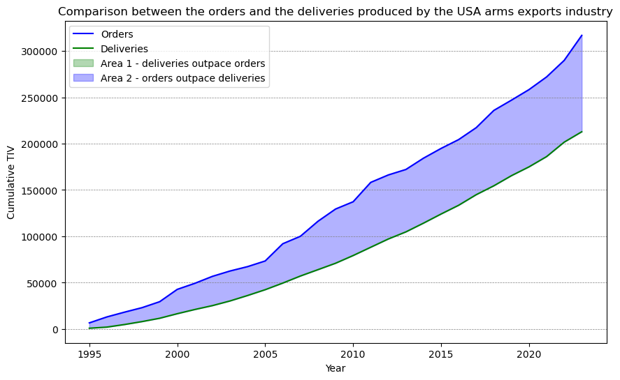

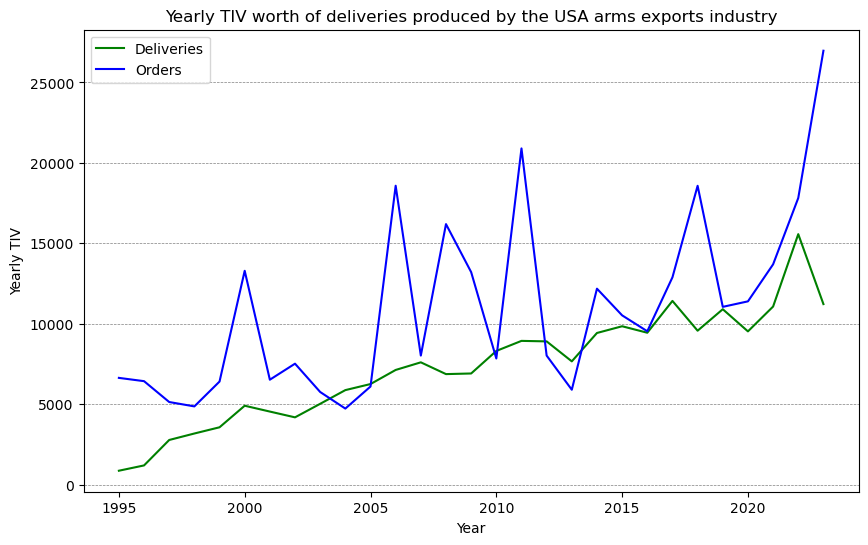

```python
#highlight the the trade offset for the biggest nation - USA
orders_dict = {}
delivaries_dict = {}
years = np.arange(cutoff_year, 2024,1)
df_orders = df_details[df_details['seller_country'] == 'United States']
df_orders = df_orders[df_orders['order_date'] >= cutoff_year]

df_orders['units_ordered'] = df_orders['units_ordered'].fillna(1)
df_delvrs = df_deliveries[df_deliveries['reference_id'].isin( df_orders['entity_id'])]

for index, row in df_orders.iterrows():
	if(int(row['order_date']) in orders_dict):
		if(math.isnan(row['units_ordered'] * row['armament_sipri_estimate'])):
			print(row['units_ordered'])
			print(row['armament_sipri_estimate'])
		orders_dict[int(row['order_date'])] += row['units_ordered'] * row['armament_sipri_estimate']
	else:
		orders_dict[int(row['order_date'])] = row['units_ordered'] * row['armament_sipri_estimate']


for index, row in df_delvrs.iterrows():
	if(int(row['year']) in delivaries_dict ):
		delivaries_dict[int(row['year'])] += row['units'] * row['tiv_per_unit']
	else:
		delivaries_dict[int(row['year'])] = row['units'] * row['tiv_per_unit']


ord_graph = []
del_graph = []

for i in range(cutoff_year,2024):
	ord_graph.append(orders_dict[i])
	del_graph.append(delivaries_dict[i])


ord_graph = np.cumsum(ord_graph)
del_graph = np.cumsum(del_graph)

plt.figure(figsize=(10, 6))

plt.plot(years, ord_graph, label='Orders', color='blue')
plt.plot(years, del_graph, label='Deliveries', color='green')

# Fill the area between the two lines
plt.fill_between(years, ord_graph, del_graph, where=(del_graph > ord_graph), color='green', alpha=0.3, interpolate=True, label='Area 1 - deliveries outpace orders')
plt.fill_between(years, del_graph,ord_graph, where=(ord_graph > del_graph), color='blue', alpha=0.3, interpolate=True, label='Area 2 - orders outpace deliveries')

plt.xlabel('Year')
plt.ylabel('Cumulative TIV')
plt.title('Comparison between the orders and the deliveries produced by the USA arms exports industry')
plt.legend()
plt.grid(True, which='both', axis='y', linestyle='--', linewidth=0.5, color='gray')

plt.show()

ord_graph = []
del_graph = []

for i in range(cutoff_year,2024):
	ord_graph.append(orders_dict[i])
	if(i in delivaries_dict):
		del_graph.append(delivaries_dict[i])
	else:
		del_graph.append(0)

# Create the plot
plt.figure(figsize=(10, 6))
width = 0.35
plt.plot(years, del_graph, label='Deliveries', color='green')
plt.plot(years, ord_graph, label='Orders', color='blue')

plt.xlabel('Year')
plt.ylabel('Yearly TIV')
plt.title('Yearly TIV worth of deliveries produced by the USA arms exports industry')
plt.legend()
plt.grid(True, which='both', axis='y', linestyle='--', linewidth=0.5, color='gray')
plt.show()
```

- The United States is comparable to IBM of the arms export market
- the large increase is in the context of the US already being the market leader
- the increase has been both in nominal TIV and in market share

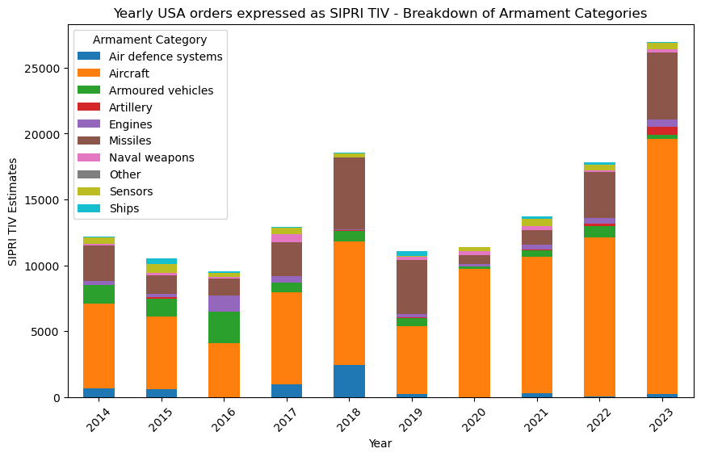

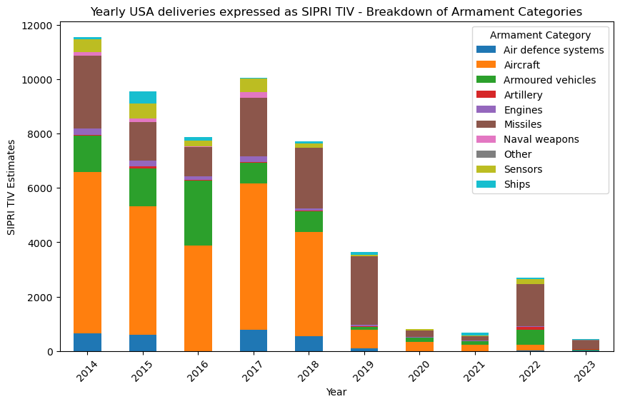

```python
#breakdown of the category of the armaments delivered and ordered - stacked column chart
df_orders = df_details[df_details['order_date'] >= 2014]
df_orders = df_orders[(df_orders['seller_country'] == 'United States')]
df_orders['units_ordered'] = df_orders['units_ordered'].fillna(1)
df_orders['total_tiv'] = df_orders['armament_sipri_estimate'] * df_orders['units_ordered']

df_delvrs = df_delvrs[df_delvrs['reference_id'].isin(df_orders['entity_id'])]
df_delvrs['total_tiv'] = df_delvrs['units'] * df_delvrs['tiv_per_unit']


df_delvrs_join = pd.merge(df_delvrs, df_orders, left_on='reference_id', right_on='entity_id', how='left')

df_summary = df_orders.groupby(['order_date', 'armament_category_name'])['total_tiv'].sum().unstack(fill_value=0)
# create a DataFrame where each column is an arms category and each row is a year
df_summary_deliv = df_delvrs_join.groupby(['order_date', 'armament_category_name'])['total_tiv_x'].sum().unstack(fill_value=0)

df_summary.plot(kind='bar', stacked=True, figsize=(10, 6))
plt.title('Yearly USA orders expressed as SIPRI TIV - Breakdown of Armament Categories')
plt.xlabel('Year')
plt.ylabel('SIPRI TIV Estimates')
plt.legend(title='Armament Category')
plt.xticks(rotation=45)

plt.show()

#deliveries
df_summary_deliv.plot(kind='bar', stacked=True, figsize=(10, 6))
plt.title('Yearly USA deliveries expressed as SIPRI TIV - Breakdown of Armament Categories')
plt.xlabel('Year')
plt.ylabel('SIPRI TIV Estimates')
plt.legend(title='Armament Category')
plt.xticks(rotation=45)

plt.show()
```

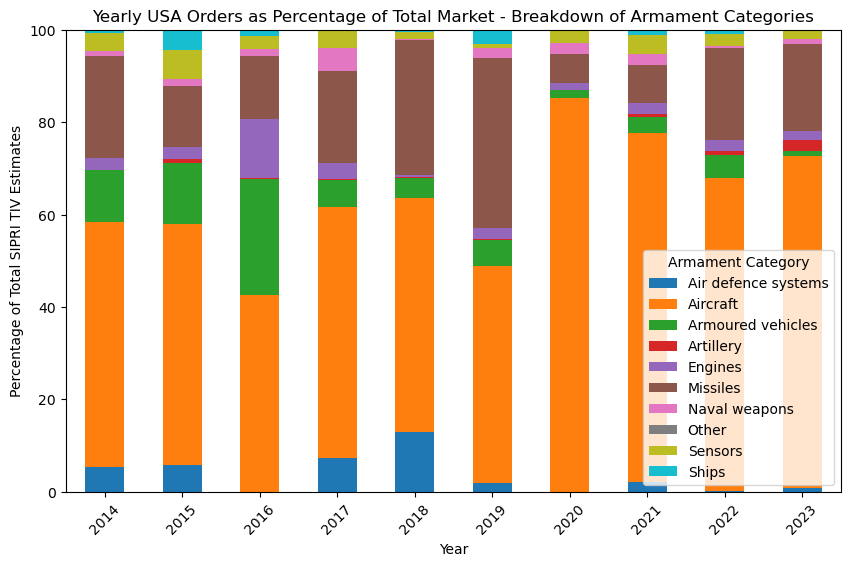

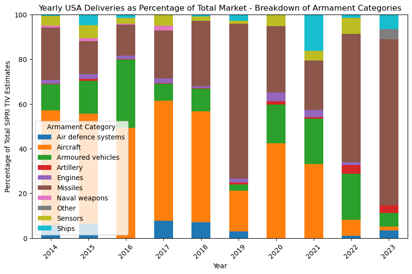

```python
#show the increase in tracked deliveries as a share of the total market - stacked column 100% chart

# Normalize
df_summary_perc = df_summary.div(df_summary.sum(axis=1), axis=0) * 100
df_summary_deliv_perc = df_summary_deliv.div(df_summary_deliv.sum(axis=1), axis=0) * 100

# orders
df_summary_perc.plot(kind='bar', stacked=True, figsize=(10, 6))
plt.title('Yearly USA Orders as Percentage of Total Market - Breakdown of Armament Categories')
plt.xlabel('Year')
plt.ylabel('Percentage of Total SIPRI TIV Estimates')
plt.legend(title='Armament Category')
plt.xticks(rotation=45)
plt.ylim(0, 100)

plt.show()

# deliveries
df_summary_deliv_perc.plot(kind='bar', stacked=True, figsize=(10, 6))
plt.title('Yearly USA Deliveries as Percentage of Total Market - Breakdown of Armament Categories')
plt.xlabel('Year')
plt.ylabel('Percentage of Total SIPRI TIV Estimates')
plt.legend(title='Armament Category')
plt.xticks(rotation=45)
plt.ylim(0, 100)

plt.show()

del df_summary_perc
del df_summary_deliv_perc
```

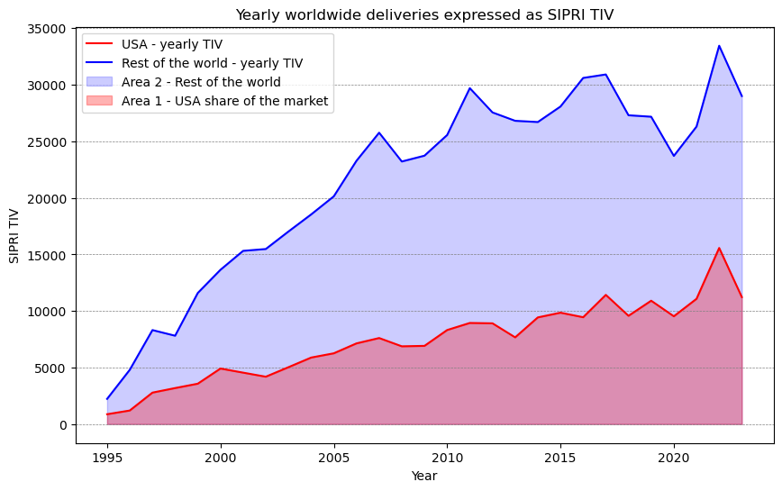

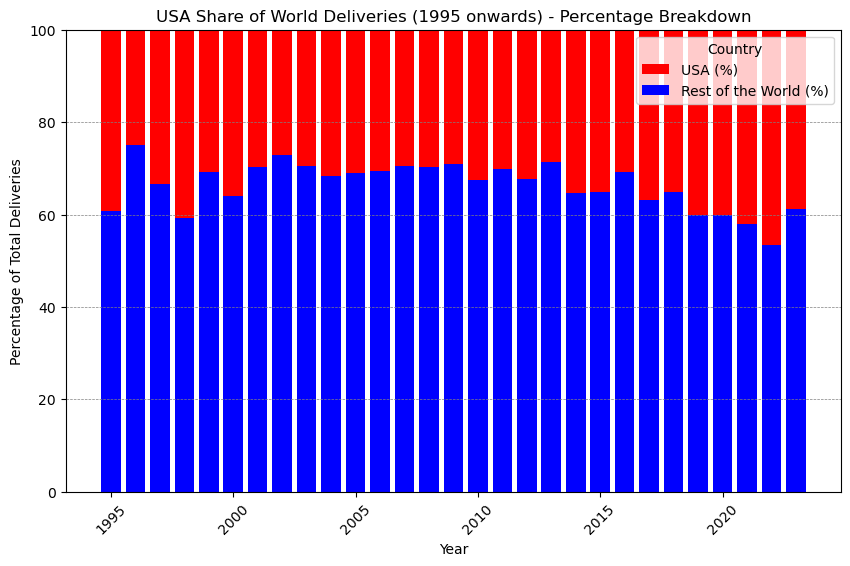

```python
#TODO show the us orders and deliveries as share of the total market
global_market = {}
global_market_array = []

usa_deliveries = {}
usa_array = []


df_orders = df_details[df_details['order_date'] >= cutoff_year]
df_orders['units_ordered'] = df_orders['units_ordered'].fillna(1)

df_delvrs = df_deliveries[df_deliveries['reference_id'].isin(df_orders['entity_id'])]
df_delvrs = df_delvrs[df_delvrs['year'] >= cutoff_year]

for _, row in df_delvrs.iterrows():
	if row['year'] in global_market:
		global_market[row['year']] += row['units'] * row['tiv_per_unit']
	else:
		global_market[row['year']] = row['units'] * row['tiv_per_unit']

years = np.arange(cutoff_year,2024,1)

for i in years:
	if i in global_market:
		global_market_array.append(global_market[i])
	else:
		global_market_array.append(0)


df_orders_usa = df_orders[df_orders['seller_country'] == 'United States']

df_deliveries_usa = df_delvrs[df_delvrs['reference_id'].isin( df_orders_usa['entity_id'])]

for _, row in df_deliveries_usa.iterrows():
	if row['year'] in usa_deliveries:
		usa_deliveries[row['year']] += row['units'] * row['tiv_per_unit']
	else:
		usa_deliveries[row['year']] = row['units'] * row['tiv_per_unit']

years = np.arange(cutoff_year,2024,1)

for i in years:
	if i in usa_deliveries:
		usa_array.append(usa_deliveries[i])
	else:
		usa_array.append(0)

# Create the plot
plt.figure(figsize=(10, 6))  # Set the figure size
width = 0.35
plt.plot(years, usa_array, color='red', label='USA - yearly TIV')
plt.plot(years, global_market_array, color='blue', label='Rest of the world - yearly TIV')

plt.fill_between(years, global_market_array, color='blue', alpha=0.2, interpolate=True, label='Area 2 - Rest of the world')
plt.fill_between(years, usa_array, color='red', alpha=0.3, interpolate=True, label='Area 1 - USA share of the market')

plt.xlabel('Year')
plt.ylabel('SIPRI TIV')
plt.title('Yearly worldwide deliveries expressed as SIPRI TIV')
plt.legend()
plt.grid(True, which='both', axis='y', linestyle='--', linewidth=0.5, color='gray')

plt.show()



# percentage for each year
percentages = pd.DataFrame({
    'Year': years,
    'USA': usa_array,
    'Rest of the World': [global_market_array[i] - usa_array[i] for i in range(len(usa_array))]
})

percentages['Total'] = percentages['USA'] + percentages['Rest of the World']
percentages['USA (%)'] = (percentages['USA'] / percentages['Total']) * 100
percentages['Rest of the World (%)'] = (percentages['Rest of the World'] / percentages['Total']) * 100

fig, ax = plt.subplots(figsize=(10, 6))
ax.bar(years, percentages['USA (%)'], label='USA (%)', color='red', bottom=percentages['Rest of the World (%)'])
ax.bar(years, percentages['Rest of the World (%)'], label='Rest of the World (%)', color='blue')

ax.set_xlabel('Year')
ax.set_ylabel('Percentage of Total Deliveries')
ax.set_title('USA Share of World Deliveries (1995 onwards) - Percentage Breakdown')
ax.legend(title='Country')
ax.set_ylim(0, 100)
plt.xticks(rotation=45)
plt.grid(True, which='both', axis='y', linestyle='--', linewidth=0.5, color='gray')

plt.show()

del usa_deliveries, usa_array, global_market, global_market_array, df_orders_usa, df_deliveries_usa, percentages
```

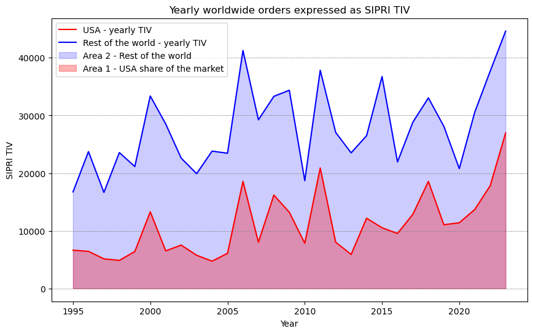

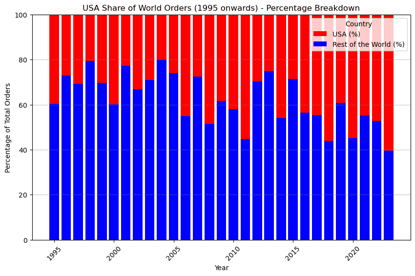

```python
#TODO show the increase in tracked anual orders as a share of the total market - stacked column 100% chart

global_market = {}
global_market_array = []

usa_orders = {}
usa_array = []


df_orders = df_details[df_details['order_date'] >= cutoff_year]
df_orders['units_ordered'] = df_orders['units_ordered'].fillna(1)


for _, row in df_orders.iterrows():
	if row['order_date'] in global_market:
		global_market[row['order_date']] += row['units_ordered'] * row['armament_sipri_estimate']
	else:
		global_market[row['order_date']] = row['units_ordered'] * row['armament_sipri_estimate']

years = np.arange(cutoff_year,2024,1)


for i in years:
	if i in global_market:
		global_market_array.append(global_market[i])
	else:
		global_market_array.append(0)


df_orders_usa = df_orders[df_orders['seller_country'] == 'United States']

for _, row in df_orders_usa.iterrows():
	if row['order_date'] in usa_orders:
		usa_orders[row['order_date']] += row['units_ordered'] * row['armament_sipri_estimate']
	else:
		usa_orders[row['order_date']] = row['units_ordered'] * row['armament_sipri_estimate']

years = np.arange(cutoff_year,2024,1)

for i in years:
	if i in usa_orders:
		usa_array.append(usa_orders[i])
	else:
		usa_array.append(0)

# Create the plot
plt.figure(figsize=(10, 6))  # Set the figure size
width = 0.35
plt.plot(years, usa_array, color='red', label='USA - yearly TIV')
plt.plot(years, global_market_array, color='blue', label='Rest of the world - yearly TIV')

plt.fill_between(years, global_market_array, color='blue', alpha=0.2, interpolate=True, label='Area 2 - Rest of the world')
plt.fill_between(years, usa_array, color='red', alpha=0.3, interpolate=True, label='Area 1 - USA share of the market')

plt.xlabel('Year')
plt.ylabel('SIPRI TIV')
plt.title('Yearly worldwide orders expressed as SIPRI TIV')
plt.legend()
plt.grid(True, which='both', axis='y', linestyle='--', linewidth=0.5, color='gray')

plt.show()


# Calculate the percentage shares for each year
percentages = pd.DataFrame({
    'Year': years,
    'USA': usa_array,
    'Rest of the World': [global_market_array[i] - usa_array[i] for i in range(len(usa_array))]
})

percentages['Total'] = percentages['USA'] + percentages['Rest of the World']
percentages['USA (%)'] = (percentages['USA'] / percentages['Total']) * 100
percentages['Rest of the World (%)'] = (percentages['Rest of the World'] / percentages['Total']) * 100

# Plot the 100% stacked bar chart
fig, ax = plt.subplots(figsize=(10, 6))
ax.bar(years, percentages['USA (%)'], label='USA (%)', color='red', bottom=percentages['Rest of the World (%)'])
ax.bar(years, percentages['Rest of the World (%)'], label='Rest of the World (%)', color='blue')

ax.set_xlabel('Year')
ax.set_ylabel('Percentage of Total Orders')
ax.set_title('USA Share of World Orders (1995 onwards) - Percentage Breakdown')
ax.legend(title='Country')
ax.set_ylim(0, 100)
plt.xticks(rotation=45)
plt.grid(True, which='both', axis='y', linestyle='--', linewidth=0.5, color='gray')

plt.show()

del usa_orders, usa_array, global_market, global_market_array, df_orders_usa, percentages
```

- The problem the American industry faces is that the industrial base is not able to keep up with the current market demands

## Russia

```
[  3641.73  12429.95  16063.46  21600.54  27417.25  30641.31  45228.97
  51342.43  55279.89  62490.73  66401.39  79108.82  86043.77  90413.37
  96951.15 101944.9  105469.4  111399.3  117662.62 120862.8  129701.9
 130871.81 133526.74 135970.66 140582.84 141423.83 142441.33 142938.55
 145053.05]
[   623.42   2756.35   4863.67   6124.48   9352.71  13256.39  18095.19
  23718.46  28716.73  34912.71  40035.04  45143.    50674.82  56640.15
  61699.46  67918.29  76675.48  84899.75  92629.22  97913.87 103650.83
 110332.25 116707.14 123607.13 128658.02 132180.18 134494.9  137098.09
 138366.79]
```

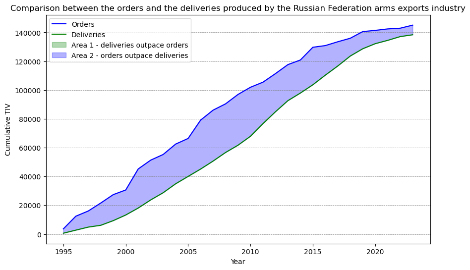

```python
orders_dict = {}
delivaries_dict = {}

df_orders = df_details[df_details['seller_country'] == 'Russia']
df_orders = df_orders[df_orders['order_date'] >= cutoff_year]

df_orders['units_ordered'] = df_orders['units_ordered'].fillna(1)
df_delvrs = df_deliveries[df_deliveries['reference_id'].isin( df_orders['entity_id'])]

df_orders


for index, row in df_orders.iterrows():
	if(int(row['order_date']) in orders_dict):
		if(math.isnan(row['units_ordered'] * row['armament_sipri_estimate'])):
			print(row['units_ordered'])
			print(row['armament_sipri_estimate'])
		orders_dict[int(row['order_date'])] += row['units_ordered'] * row['armament_sipri_estimate']
	else:
		orders_dict[int(row['order_date'])] = row['units_ordered'] * row['armament_sipri_estimate']


for index, row in df_delvrs.iterrows():
	if(int(row['year']) in delivaries_dict ):
		delivaries_dict[int(row['year'])] += row['units'] * row['tiv_per_unit']
	else:
		delivaries_dict[int(row['year'])] = row['units'] * row['tiv_per_unit']


ord_graph = []
del_graph = []

for i in range(cutoff_year,2024):
	ord_graph.append(orders_dict[i])
	if(i in delivaries_dict):
		del_graph.append(delivaries_dict[i])
	else:
		del_graph.append(0)

ord_graph = np.cumsum(ord_graph)
del_graph = np.cumsum(del_graph)




plt.figure(figsize=(10, 6))
plt.plot(years, ord_graph, label='Orders', color='blue')
plt.plot(years, del_graph, label='Deliveries', color='green')

# Fill the area between the two lines
plt.fill_between(years, ord_graph, del_graph, where=(del_graph > ord_graph), color='green', alpha=0.3, interpolate=True, label='Area 1 - deliveries outpace orders')
plt.fill_between(years, del_graph,ord_graph, where=(ord_graph > del_graph), color='blue', alpha=0.3, interpolate=True, label='Area 2 - orders outpace deliveries')

plt.xlabel('Year')
plt.ylabel('Cumulative TIV')
plt.title('Comparison between the orders and the deliveries produced by the Russian Federation arms exports industry')
plt.legend()
plt.grid(True, which='both', axis='y', linestyle='--', linewidth=0.5, color='gray')

plt.show()
```

- Let's keep exploring the exports of the russian arms industry.
- Keep in mind these are cumulative values to track the evolution of deliveries against orders.
- So let's look at non cumulative yearly orders numbers.

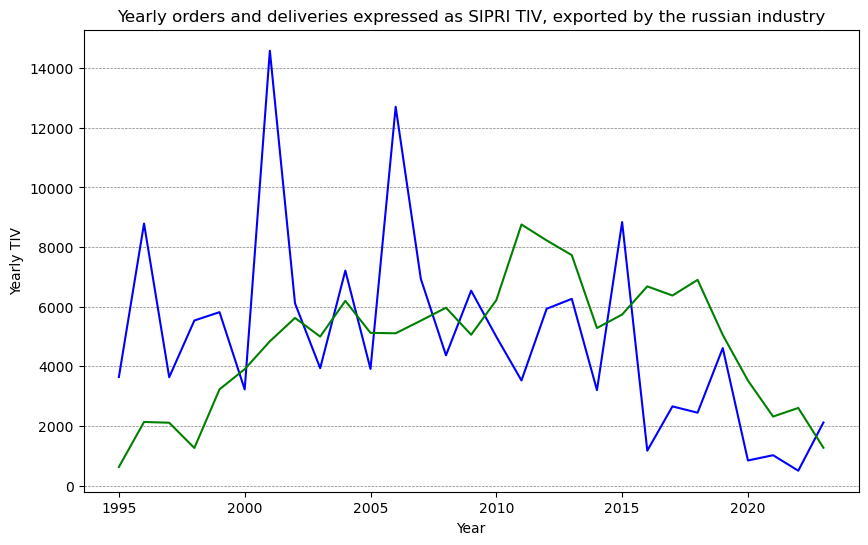

```python
ord_graph = []
del_graph = []


for i in range(cutoff_year,2024):
	if(i in orders_dict):
		ord_graph.append(orders_dict[i])
	else:
		ord_graph.append(0)

for i in range(cutoff_year,2024):
	if(i in delivaries_dict):
		del_graph.append(delivaries_dict[i])
	else:
		del_graph.append(0)

plt.figure(figsize=(10, 6))
width = 0.35

plt.plot(years, ord_graph, label='', color='blue')
plt.plot(years, del_graph, label='', color='green')

plt.xlabel('Year')
plt.ylabel('Yearly TIV')
plt.title('Yearly orders and deliveries expressed as SIPRI TIV, exported by the russian industry')

plt.grid(True, which='both', axis='y', linestyle='--', linewidth=0.5, color='gray')

plt.show()
```

- The observed decrease in deliveries comes at a time when a conventional war in Europe has raised the uncertainty level and therefore security needs.
- This can be observed with the growth of the overall world market

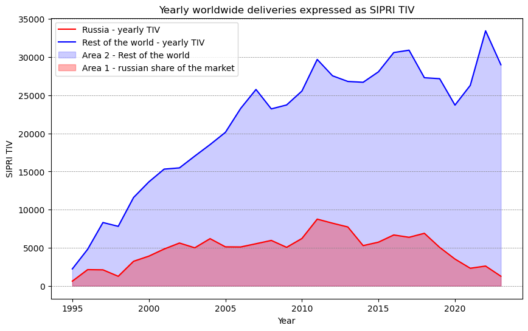

```python
global_market = {}
global_market_array = []

russian_deliveries = {}
russian_array = []


df_orders = df_details[df_details['order_date'] >= cutoff_year]
df_orders['units_ordered'] = df_orders['units_ordered'].fillna(1)

df_delvrs = df_deliveries[df_deliveries['reference_id'].isin(df_orders['entity_id'])]
df_delvrs = df_delvrs[df_delvrs['year'] >= cutoff_year]

for _, row in df_delvrs.iterrows():
	if row['year'] in global_market:
		global_market[row['year']] += row['units'] * row['tiv_per_unit']
	else:
		global_market[row['year']] = row['units'] * row['tiv_per_unit']

years = np.arange(cutoff_year,2024,1)

for i in years:
	if i in global_market:
		global_market_array.append(global_market[i])
	else:
		global_market_array.append(0)


df_orders_russia = df_orders[df_orders['seller_country'] == 'Russia']

df_deliveries_russia = df_delvrs[df_delvrs['reference_id'].isin( df_orders_russia['entity_id'])]

for _, row in df_deliveries_russia.iterrows():
	if row['year'] in russian_deliveries:
		russian_deliveries[row['year']] += row['units'] * row['tiv_per_unit']
	else:
		russian_deliveries[row['year']] = row['units'] * row['tiv_per_unit']

years = np.arange(cutoff_year,2024,1)

for i in years:
	if i in russian_deliveries:
		russian_array.append(russian_deliveries[i])
	else:
		russian_array.append(0)

plt.figure(figsize=(10, 6))
width = 0.35
plt.plot(years, russian_array, color='red', label='Russia - yearly TIV')
plt.plot(years, global_market_array, color='blue', label='Rest of the world - yearly TIV')

plt.fill_between(years, global_market_array, color='blue', alpha=0.2, interpolate=True, label='Area 2 - Rest of the world')
plt.fill_between(years, russian_array, color='red', alpha=0.3, interpolate=True, label='Area 1 - russian share of the market')

plt.xlabel('Year')
plt.ylabel('SIPRI TIV')
plt.title('Yearly worldwide deliveries expressed as SIPRI TIV')
plt.legend()
plt.grid(True, which='both', axis='y', linestyle='--', linewidth=0.5, color='gray')

plt.show()
```

[figure not shown]

[figure not shown]

```python
# Filter the DataFrame for rows where Russia is the seller
russia_deliveries = df_join_deliveries[df_join_deliveries['seller_country'] == 'Russia']
russia_deliveries['units_ordered'] = russia_deliveries['units_ordered'].fillna(1)

russia_deliveries_peak = russia_deliveries[(russia_deliveries['order_date'] == 2013)]
russia_deliveries_current = russia_deliveries[(russia_deliveries['order_date'] == 2023) | (russia_deliveries['order_date'] == 2022)]


# Group by 'buyer_country' to get the count of transactions
delivery_partners_peak = {}
delivery_partners_current = {}

threshold = 45

for _, row in russia_deliveries_peak.iterrows():
	if(row['reference_id'] > 0):
		if row['buyer_country'] in delivery_partners_peak:
			delivery_partners_peak[row['buyer_country']] += row['units'] * row['tiv_per_unit']
		else:
			delivery_partners_peak[row['buyer_country']] = row['units'] * row['tiv_per_unit']

for _, row in russia_deliveries_current.iterrows():
	if(row['reference_id'] > 0):
		if row['buyer_country'] in delivery_partners_current:
			delivery_partners_current[row['buyer_country']] += row['units'] * row['tiv_per_unit']
		else:
			delivery_partners_current[row['buyer_country']] = row['units'] * row['tiv_per_unit']

# create "Others"
others = 0
new_data = {}
others_counter = 0
for country, value in delivery_partners_peak.items():
	if value < threshold:
		others += value
		others_counter += 1
	else:
		new_data[country] = value
if others > 0:
    new_data['Others '+str(others_counter)+' countries'] = others
delivery_partners_peak = new_data

lbls = zip(list(delivery_partners_peak.keys()), list(delivery_partners_peak.values()))
lbls = [l[0]+'-'+str(l[1]) for l in list(lbls)]
sizes = list(delivery_partners_peak.values())
colors = plt.cm.Paired(range(len(lbls)))

plt.figure(figsize=(10, 8))
plt.pie(sizes, labels=lbls, colors=colors, autopct='%1.1f%%', startangle=140)
plt.axis('equal')
plt.title('SIPRI TIV Distribution of Russian partners taking deliveries - Before Crimea')
plt.show()

# Prepare data
lbls = []
lbls = zip(list(delivery_partners_current.keys()), list(delivery_partners_current.values()))
lbls = [l[0]+'-'+str(l[1]) for l in list(lbls)]
sizes = list(delivery_partners_current.values())
colors = plt.cm.Paired(range(len(lbls)))

plt.figure(figsize=(10, 8))
plt.pie(sizes, labels=lbls, colors=colors, autopct='%1.1f%%', startangle=140)
plt.axis('equal')
plt.title('SIPRI TIV Distribution of Russian partners taking deliveries - Current')
plt.show()
```

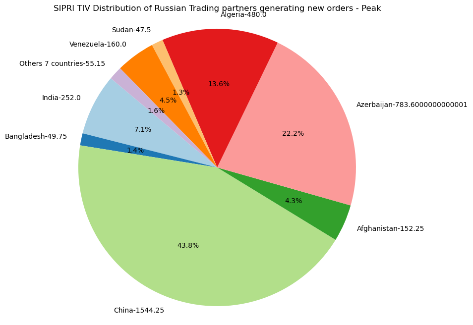

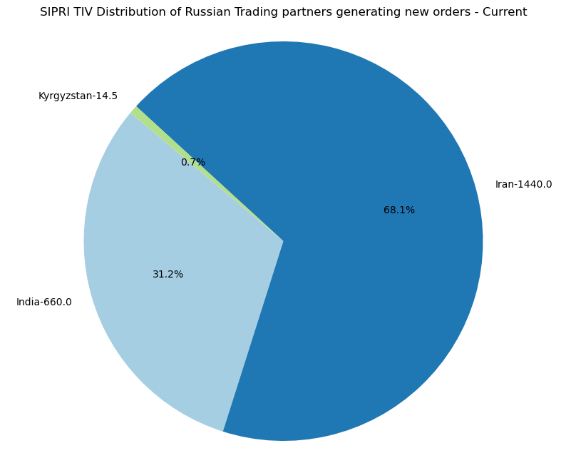

```python
# Filter the DataFrame for rows where Russia is the seller
russia_sellers = df_details[df_details['seller_country'] == 'Russia']
#remove the
russia_sellers_peak = russia_sellers[(russia_sellers['order_date'] == 2011)]
russia_sellers_current = russia_sellers[(russia_sellers['order_date'] == 2023)]

# Group by 'buyer_country' to get the count of transactions
trading_partners_peak = {}
trading_partners_current = {}

threshold = 45
others = 0
new_data = {}

for _, row in russia_sellers_peak.iterrows():
	if row['buyer_country'] in trading_partners_peak:
		trading_partners_peak[row['buyer_country']] += row['armament_sipri_estimate'] * row['units_ordered']
	else:
		trading_partners_peak[row['buyer_country']] = row['armament_sipri_estimate'] * row['units_ordered']

for _, row in russia_sellers_current.iterrows():
	if row['buyer_country'] in trading_partners_current:
		trading_partners_current[row['buyer_country']] += row['armament_sipri_estimate'] * row['units_ordered']
	else:
		trading_partners_current[row['buyer_country']] = row['armament_sipri_estimate'] * row['units_ordered']

# create "Others"
others_counter = 0
for country, value in trading_partners_peak.items():
	if value < threshold:
		others += value
		others_counter += 1
	else:
		new_data[country] = value

if others > 0:
    new_data['Others '+str(others_counter)+' countries'] = others

# peak
trading_partners_peak = new_data
lbls = zip(list(trading_partners_peak.keys()), list(trading_partners_peak.values()))
lbls = [l[0]+'-'+str(l[1]) for l in list(lbls)]
sizes = list(trading_partners_peak.values())
colors = plt.cm.Paired(range(len(lbls)))

plt.figure(figsize=(10, 8))
plt.pie(sizes, labels=lbls, colors=colors, autopct='%1.1f%%', startangle=140)
plt.axis('equal')
plt.title('SIPRI TIV Distribution of Russian Trading partners generating new orders - Peak')
plt.show()

# current
lbls = zip(list(trading_partners_current.keys()), list(trading_partners_current.values()))
lbls = [l[0]+'-'+str(l[1]) for l in list(lbls)]
sizes = list(trading_partners_current.values())
colors = plt.cm.Paired(range(len(lbls)))

plt.figure(figsize=(10, 8))
plt.pie(sizes, labels=lbls, colors=colors, autopct='%1.1f%%', startangle=140)
plt.axis('equal')
plt.title('SIPRI TIV Distribution of Russian Trading partners generating new orders - Current')
plt.show()
```

Observations:

- The indian orders are part of the expansion of India's license built Sukoi 30 programme.
- The situation for Russia changed drastically going from a favoured supplier for 12+ countries to a single, to a supplier for mainly a single sactions ridden country

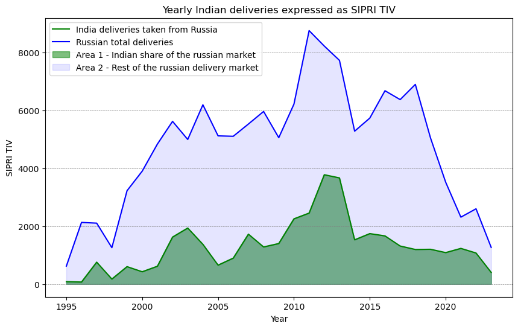

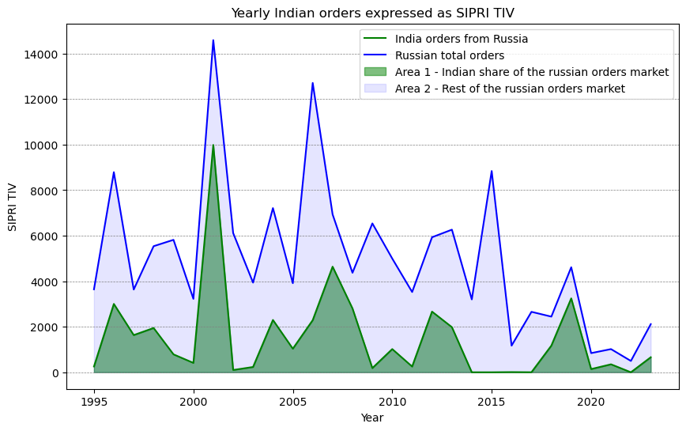

```python
russian_market = {}
russian_market_array = []

india_deliveries = {}
india_array = []
years = np.arange(cutoff_year,2024,1)

df_orders = df_details[df_details['order_date'] >= cutoff_year]
df_orders = df_orders[(df_orders['seller_country'] == 'Russia')]
df_orders['units_ordered'] = df_orders['units_ordered'].fillna(1)

df_delvrs = df_deliveries[df_deliveries['reference_id'].isin(df_orders['entity_id'])]
df_delvrs = df_delvrs[df_delvrs['year'] >= cutoff_year]

for _, row in df_delvrs.iterrows():
	if row['year'] in russian_market:
		russian_market[row['year']] += row['units'] * row['tiv_per_unit']
	else:
		russian_market[row['year']] = row['units'] * row['tiv_per_unit']
for i in years:
	if i in russian_market:
		russian_market_array.append(russian_market[i])
	else:
		russian_market_array.append(0)


df_orders_india = df_orders[(df_orders['buyer_country'] == 'India')]
df_delvrs_india = df_delvrs[df_delvrs['reference_id'].isin( df_orders_india['entity_id'])]

for _, row in df_delvrs_india.iterrows():
	if row['year'] in india_deliveries:
		india_deliveries[row['year']] += row['units'] * row['tiv_per_unit']
	else:
		india_deliveries[row['year']] = row['units'] * row['tiv_per_unit']
for i in years:
	if i in india_deliveries:
		india_array.append(india_deliveries[i])
	else:
		india_array.append(0)

### Deliveries
plt.figure(figsize=(10, 6))
plt.plot(years, india_array, color='green', label='India deliveries taken from Russia')
plt.plot(years, russian_market_array, color='blue', label='Russian total deliveries')
plt.fill_between(years, india_array, color='green', alpha=0.5, interpolate=True, label='Area 1 - Indian share of the russian market')
plt.fill_between(years, russian_market_array, color='blue', alpha=0.1, interpolate=True, label='Area 2 - Rest of the russian delivery market')

plt.xlabel('Year')
plt.ylabel('SIPRI TIV')
plt.title('Yearly Indian deliveries expressed as SIPRI TIV')
plt.legend()
plt.grid(True, which='both', axis='y', linestyle='--', linewidth=0.5, color='gray')

plt.show()




russian_market = {}
russian_market_array = []

india_orders = {}
india_array = []

df_orders = df_details[df_details['order_date'] >= cutoff_year]
df_orders = df_orders[(df_orders['seller_country'] == 'Russia')]
df_orders['units_ordered'] = df_orders['units_ordered'].fillna(1)

for _, row in df_orders.iterrows():
	if row['order_date'] in russian_market:
		russian_market[row['order_date']] += row['units_ordered'] * row['armament_sipri_estimate']
	else:
		russian_market[row['order_date']] = row['units_ordered'] * row['armament_sipri_estimate']
for i in years:
	if i in russian_market:
		russian_market_array.append(russian_market[i])
	else:
		russian_market_array.append(0)


df_orders_india = df_orders[(df_orders['buyer_country'] == 'India')]


for _, row in df_orders_india.iterrows():
	if row['order_date'] in india_orders:
		india_orders[row['order_date']] += row['units_ordered'] * row['armament_sipri_estimate']
	else:
		india_orders[row['order_date']] = row['units_ordered'] * row['armament_sipri_estimate']
for i in years:
	if i in india_orders:
		india_array.append(india_orders[i])
	else:
		india_array.append(0)

### Orders
plt.figure(figsize=(10, 6))
plt.plot(years, india_array, color='green', label='India orders from Russia')
plt.plot(years, russian_market_array, color='blue', label='Russian total orders')
plt.fill_between(years, india_array, color='green', alpha=0.5, interpolate=True, label='Area 1 - Indian share of the russian orders market')
plt.fill_between(years, russian_market_array, color='blue', alpha=0.1, interpolate=True, label='Area 2 - Rest of the russian orders market')

plt.xlabel('Year')
plt.ylabel('SIPRI TIV')
plt.title('Yearly Indian orders expressed as SIPRI TIV')
plt.legend()
plt.grid(True, which='both', axis='y', linestyle='--', linewidth=0.5, color='gray')

plt.show()
```

- The world has been reducind their dependence on russia
- India has been doing the same but slower in the 2014-present period

[figure not shown]

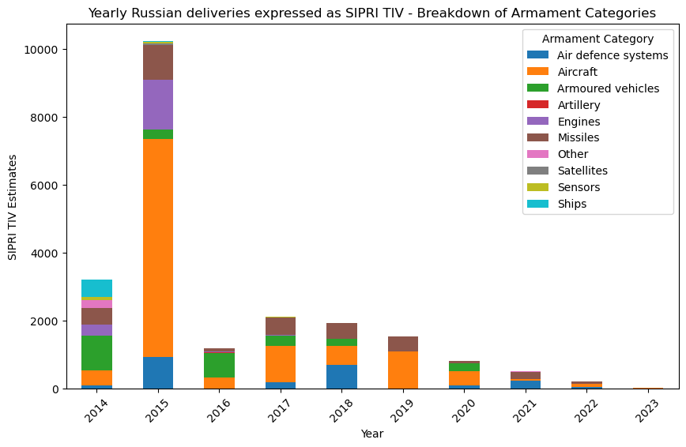

```python
df_orders = df_details[df_details['order_date'] >= 2014]
df_orders = df_orders[(df_orders['seller_country'] == 'Russia')]
df_orders['units_ordered'] = df_orders['units_ordered'].fillna(1)
df_orders['total_tiv'] = df_orders['armament_sipri_estimate'] * df_orders['units_ordered']
df_delvrs = df_delvrs[df_delvrs['reference_id'].isin(df_orders['entity_id'])]
df_delvrs['total_tiv'] = df_delvrs['units'] * df_delvrs['tiv_per_unit']


df_delvrs_join = pd.merge(df_delvrs, df_orders, left_on='reference_id', right_on='entity_id', how='left')

df_summary = df_orders.groupby(['order_date', 'armament_category_name'])['total_tiv'].sum().unstack(fill_value=0)
df_summary_deliv = df_delvrs_join.groupby(['order_date', 'armament_category_name'])['total_tiv_x'].sum().unstack(fill_value=0)

#orders
df_summary.plot(kind='bar', stacked=True, figsize=(10, 6))
plt.title('Yearly Russian orders expressed as SIPRI TIV - Breakdown of Armament Categories')
plt.xlabel('Year')
plt.ylabel('SIPRI TIV Estimates')
plt.legend(title='Armament Category')
plt.xticks(rotation=45)
plt.show()

#deliveries
df_summary_deliv.plot(kind='bar', stacked=True, figsize=(10, 6))
plt.title('Yearly Russian deliveries expressed as SIPRI TIV - Breakdown of Armament Categories')
plt.xlabel('Year')
plt.ylabel('SIPRI TIV Estimates')
plt.legend(title='Armament Category')
plt.xticks(rotation=45)
plt.show()
```

## South Korea

```
[   70.6     70.6    102.6    282.6    332.6    453.45  1681.95  1681.95
  1686.95  2068.95  2108.05  2108.05  2184.65  2225.95  2260.15  2297.35
  3196.49  3971.19  4789.44  5004.    5135.2   5851.1   6844.45  6989.48
  7492.98  7512.09  7929.42 17210.25 18920.03]
[  21.35   45.35   70.6   102.6   102.6   112.2   342.2   342.2   438.45
  512.89  621.95  780.11 1057.77 1167.63 1391.88 1569.28 1897.53 2100.35
 2450.75 2670.77 2764.47 3200.97 3902.63 4951.59 5633.48 6405.86 6916.29
 7119.92 7740.47]
```

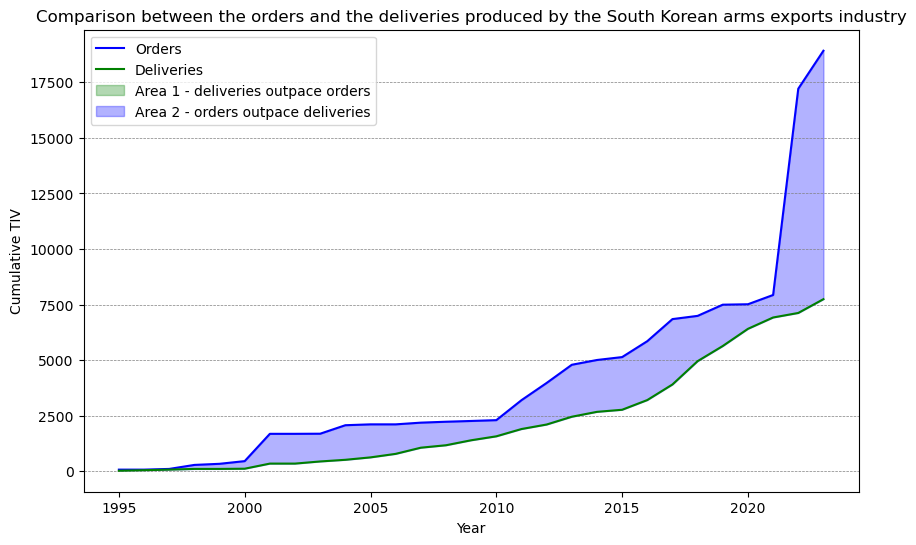

```python
orders_dict = {}
delivaries_dict = {}

df_orders = df_details[df_details['seller_country'] == 'South Korea']
df_orders = df_orders[df_orders['order_date'] >= cutoff_year]

df_orders['units_ordered'] = df_orders['units_ordered'].fillna(1)
df_delvrs = df_deliveries[df_deliveries['reference_id'].isin( df_orders['entity_id'])]


for index, row in df_orders.iterrows():
	if(int(row['order_date']) in orders_dict):
		if(math.isnan(row['units_ordered'] * row['armament_sipri_estimate'])):
			print(row['units_ordered'])
			print(row['armament_sipri_estimate'])
		orders_dict[int(row['order_date'])] += row['units_ordered'] * row['armament_sipri_estimate']
	else:
		orders_dict[int(row['order_date'])] = row['units_ordered'] * row['armament_sipri_estimate']


for index, row in df_delvrs.iterrows():
	if(int(row['year']) in delivaries_dict ):
		delivaries_dict[int(row['year'])] += row['units'] * row['tiv_per_unit']
	else:
		delivaries_dict[int(row['year'])] = row['units'] * row['tiv_per_unit']


ord_graph = []
del_graph = []

for i in range(cutoff_year,2024):
	if i in orders_dict:
		ord_graph.append(orders_dict[i])
	else:
		ord_graph.append(0)
	if(i in delivaries_dict):
		del_graph.append(delivaries_dict[i])
	else:
		del_graph.append(0)

ord_graph = np.cumsum(ord_graph)
del_graph = np.cumsum(del_graph)


plt.figure(figsize=(10, 6))

plt.plot(years, ord_graph, label='Orders', color='blue')
plt.plot(years, del_graph, label='Deliveries', color='green')

plt.fill_between(years, ord_graph, del_graph, where=(del_graph > ord_graph), color='green', alpha=0.3, interpolate=True, label='Area 1 - deliveries outpace orders')
plt.fill_between(years, del_graph, ord_graph, where=(ord_graph > del_graph), color='blue', alpha=0.3, interpolate=True, label='Area 2 - orders outpace deliveries')

plt.xlabel('Year')
plt.ylabel('Cumulative TIV')
plt.title('Comparison between the orders and the deliveries produced by the South Korean arms exports industry')
plt.legend()
plt.grid(True, which='both', axis='y', linestyle='--', linewidth=0.5, color='gray')

plt.show()
```